# GoodLife Fitness: Optimizing Gym Equipment Utilization

## Objective

The goal of this project is to predict how crowded the gym will be at any given time, allowing GoodLife Fitness to better manage gym resources and encourage members to visit during less crowded times. By accurately predicting gym occupancy, the club can improve member satisfaction, reduce equipment wear, and optimize staff scheduling.

## Dataset Overview

The dataset contains the following features:

- **date**: The date of the observation.
- **timestamp**: The number of seconds since the beginning of the day.
- **day_of_week**: The day of the week (0 = Monday, 6 = Sunday).
- **is_weekend**: A boolean indicating if the day is a weekend (1) or not (0).
- **is_holiday**: A boolean indicating if the day is a federal holiday (1) or not (0).
- **temperature**: The temperature in Fahrenheit.
- **is_start_of_semester**: A boolean indicating if it is the beginning of a school semester (1) or not (0).
- **month**: The month of the observation (1 = January, 12 = December).
- **hour**: The hour of the day (0 - 23).
- **number_of_people**: The target variable, representing the number of people in the gym at the given time.

## Steps to Follow

```python
import pandas as pd

# Load the dataset for Problem B
data_path = '../data/problem2.csv'
data = pd.read_csv(data_path)

# Display the first few rows of the dataset
print("First few rows of the dataset:")
print(data.head())

# Display a summary of the dataset including data types and missing values
print("\nSummary of the dataset:")
print(data.info())

# Display basic statistics of the dataset
print("\nBasic statistics of the dataset:")
print(data.describe())
```

```
First few rows of the dataset:
   number_people                       date  timestamp  day_of_week  \
0             37  2015-08-14 17:00:11-07:00      61211            4
1             45  2015-08-14 17:20:14-07:00      62414            4
2             40  2015-08-14 17:30:15-07:00      63015            4
3             44  2015-08-14 17:40:16-07:00      63616            4
4             45  2015-08-14 17:50:17-07:00      64217            4

   is_weekend  is_holiday  temperature  is_start_of_semester  \
0           0           0        71.76                     0
1           0           0        71.76                     0
2           0           0        71.76                     0
3           0           0        71.76                     0
4           0           0        71.76                     0

   is_during_semester  month  hour
0                   0      8    17
1                   0      8    17
2                   0      8    17
3                   0      8    17
4                   0      8    17

Summary of the dataset:
<class 'pandas.core.frame.DataFrame'>
RangeIndex: 62184 entries, 0 to 62183
Data columns (total 11 columns):
 #   Column                Non-Null Count  Dtype
---  ------                --------------  -----
 0   number_people         62184 non-null  int64
 1   date                  62184 non-null  object
 2   timestamp             62184 non-null  int64
 3   day_of_week           62184 non-null  int64
 4   is_weekend            62184 non-null  int64
 5   is_holiday            62184 non-null  int64
 6   temperature           62184 non-null  float64
 7   is_start_of_semester  62184 non-null  int64
 8   is_during_semester    62184 non-null  int64
 9   month                 62184 non-null  int64
 10  hour                  62184 non-null  int64
dtypes: float64(1), int64(9), object(1)
```

[output cut: 18 more lines]

```
min       38.140000              0.000000            0.000000      1.000000
25%       55.000000              0.000000            0.000000      5.000000
50%       58.340000              0.000000            1.000000      8.000000
75%       62.280000              0.000000            1.000000     10.000000
max       87.170000              1.000000            1.000000     12.000000

               hour
count  62184.000000
mean      12.236460
std        6.717631
min        0.000000
25%        7.000000
50%       12.000000
75%       18.000000
max       23.000000
```

## Initial Data Analysis

### Key Observations:

1. **Dataset Overview:**
   - The dataset contains **62,184** entries with 11 features, including the target variable `number_people`, which represents the number of people in the gym at a given time.
   - The `date` column is currently of type `object` and may need to be converted to a datetime format for further analysis.
2. **Data Types:**
   - The dataset primarily consists of numerical features, with `float64` and `int64` types dominating. The `date` column is an exception, currently stored as a string (`object`).
3. **Missing Values:**
   - There are no missing values in the dataset, which simplifies the preprocessing steps.
4. **Basic Statistics:**
   - The `number_people` variable ranges from 0 to 145, with a mean of approximately 29 people in the gym at any given time.
   - The `temperature` variable ranges from 38.14°F to 87.17°F, with a mean temperature of approximately 58.56°F.
   - The dataset includes both weekend and holiday indicators, as well as indicators for whether it is the start of a semester or during the semester.

### Next Steps:

1. **Data Preprocessing:**
   - Convert the `date` column to a datetime format.
   - Extract additional features from the `date` column, such as `day`, `week`, and `year`, which could be useful in modeling.
   - Scale continuous variables like `temperature` and `timestamp` to ensure uniformity in model training.
   - Consider encoding the `day_of_week` and `month` columns as categorical variables for the model.
2. **Exploratory Data Analysis (EDA):**
   - Perform EDA to understand the relationships between the features and the target variable (`number_people`), which will inform feature engineering and model selection.

```python
import pandas as pd
from datetime import datetime

# Inspect the first few entries in the 'date' column
print("\nSample data from 'date' column:")
print(data['date'].head(10))

# Attempt to convert 'date' column with utc=True
data['date'] = pd.to_datetime(data['date'], errors='coerce', utc=True)

# If still not recognized, manually parse using apply and strptime
if not pd.api.types.is_datetime64_any_dtype(data['date']):
    # Attempt manual conversion with known format
    try:
        data['date'] = data['date'].apply(lambda x: datetime.strptime(x, '%Y-%m-%d %H:%M:%S%z'))
    except Exception as e:
        print(f"Error during manual parsing: {e}")

# Check if conversion was successful
print("\nData types after attempting to convert 'date' to datetime with utc=True or manual parsing:")
print(data.dtypes)

# Proceed if successful
if pd.api.types.is_datetime64_any_dtype(data['date']):
    data['date'] = data['date'].dt.tz_localize(None)
    data['day'] = data['date'].dt.day
    data['week'] = data['date'].dt.isocalendar().week
    data['year'] = data['date'].dt.year

    # Scaling 'temperature' and 'timestamp'
    from sklearn.preprocessing import StandardScaler
    scaler = StandardScaler()
    data[['temperature', 'timestamp']] = scaler.fit_transform(data[['temperature', 'timestamp']])

    print("\nData after preprocessing:")
    print(data.head())
else:
    print("\nThe 'date' column is still not recognized as a datetime object.")
```

```
Sample data from 'date' column:
0    2015-08-14 17:00:11-07:00
1    2015-08-14 17:20:14-07:00
2    2015-08-14 17:30:15-07:00
3    2015-08-14 17:40:16-07:00
4    2015-08-14 17:50:17-07:00
5    2015-08-14 18:00:18-07:00
6    2015-08-14 18:20:08-07:00
7    2015-08-14 18:30:09-07:00
8    2015-08-14 18:40:14-07:00
9    2015-08-14 18:50:15-07:00
Name: date, dtype: object

Data types after attempting to convert 'date' to datetime with utc=True or manual parsing:
number_people                         int64
date                    datetime64[ns, UTC]
timestamp                             int64
day_of_week                           int64
is_weekend                            int64
is_holiday                            int64
temperature                         float64
is_start_of_semester                  int64
is_during_semester                    int64
month                                 int64
hour                                  int64
dtype: object

Data after preprocessing:
   number_people                date  timestamp  day_of_week  is_weekend  \
0             37 2015-08-15 00:00:11   0.636550            4           0
1             45 2015-08-15 00:20:14   0.686238            4           0
2             40 2015-08-15 00:30:15   0.711061            4           0
3             44 2015-08-15 00:40:16   0.735885            4           0
4             45 2015-08-15 00:50:17   0.760708            4           0

   is_holiday  temperature  is_start_of_semester  is_during_semester  month  \
0           0     2.090274                     0                   0      8
1           0     2.090274                     0                   0      8
2           0     2.090274                     0                   0      8
3           0     2.090274                     0                   0      8
4           0     2.090274                     0                   0      8

   hour  day  week  year
0    17   15    33  2015
1    17   15    33  2015
2    17   15    33  2015
3    17   15    33  2015
4    17   15    33  2015
```

## Data Preprocessing Analysis

### Key Observations:

1. **Date Conversion and Feature Extraction:**
   - The `date` column was successfully converted to a datetime format, and the timezone information was removed.
   - Additional features were extracted from the `date` column, including `day`, `week`, and `year`, which may provide valuable information for predicting gym occupancy.
2. **Feature Scaling:**
   - The `timestamp` and `temperature` columns were scaled using standardization, which normalizes these features to have a mean of 0 and a standard deviation of 1. This ensures that these features contribute equally to the model during training.
3. **Data Types:**
   - All features have the correct data types, with the newly extracted features (`day`, `week`, `year`) correctly formatted as numerical values.

## Exploratory Data Analysis (EDA)

### Distribution of Key Features

We will begin by visualizing the distribution of key features in the dataset to understand their spread and any patterns that might emerge. This includes:

- `number_people`: The target variable representing the number of people in the gym.
- `temperature`: The temperature at the time of data collection.
- `day_of_week`: The day of the week.
- `hour`: The hour of the day.

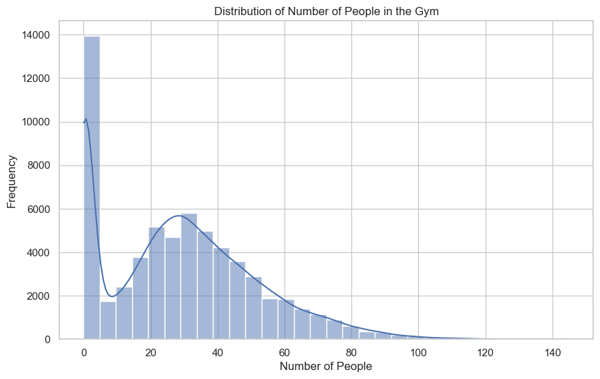

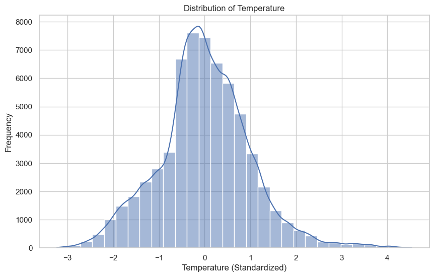

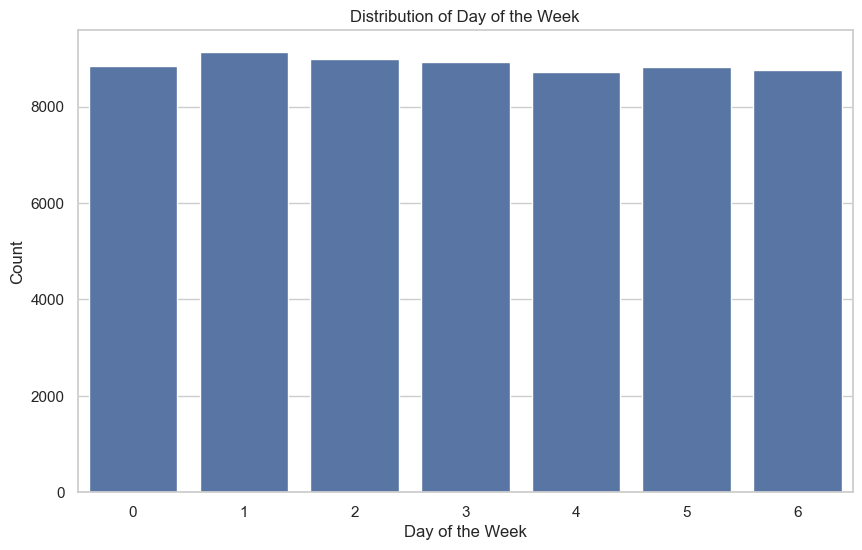

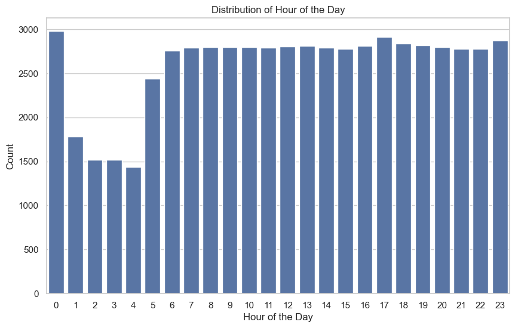

```python
import matplotlib.pyplot as plt
import seaborn as sns

# Set the style for seaborn
sns.set(style="whitegrid")

# Plot the distribution of 'number_people'
plt.figure(figsize=(10, 6))
sns.histplot(data['number_people'], bins=30, kde=True)
plt.title('Distribution of Number of People in the Gym')
plt.xlabel('Number of People')
plt.ylabel('Frequency')
plt.show()

# Plot the distribution of 'temperature'
plt.figure(figsize=(10, 6))
sns.histplot(data['temperature'], bins=30, kde=True)
plt.title('Distribution of Temperature')
plt.xlabel('Temperature (Standardized)')
plt.ylabel('Frequency')
plt.show()

# Plot the distribution of 'day_of_week'
plt.figure(figsize=(10, 6))
sns.countplot(x='day_of_week', data=data)
plt.title('Distribution of Day of the Week')
plt.xlabel('Day of the Week')
plt.ylabel('Count')
plt.show()

# Plot the distribution of 'hour'
plt.figure(figsize=(10, 6))
sns.countplot(x='hour', data=data)
plt.title('Distribution of Hour of the Day')
plt.xlabel('Hour of the Day')
plt.ylabel('Count')
plt.show()
```

### Relationships Between Features

We'll visualize how key features like `temperature`, `day_of_week`, and `hour` relate to `number_people` to identify any potential correlations or patterns.

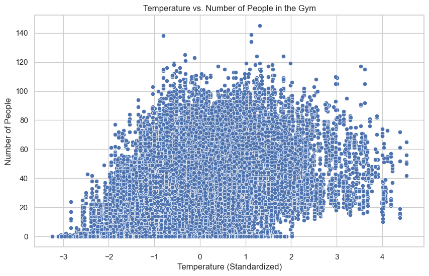

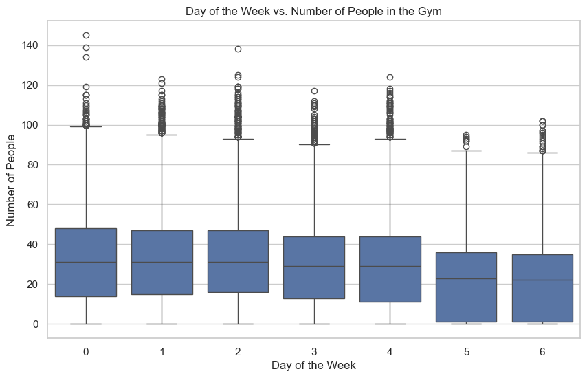

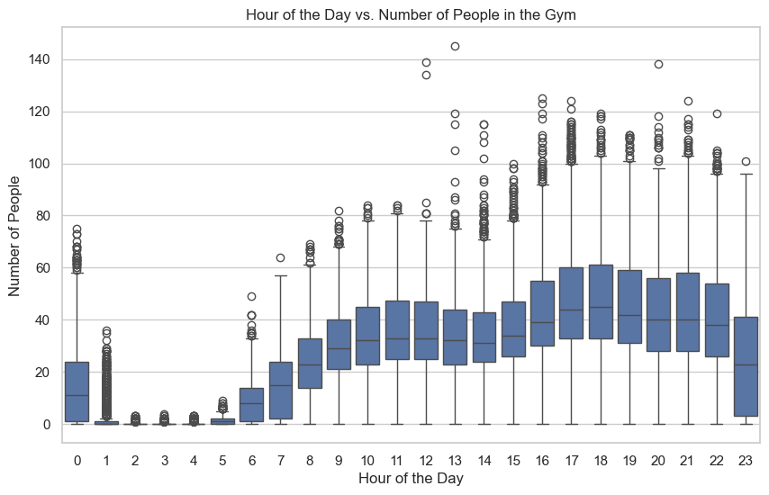

```python
# Plot relationship between 'temperature' and 'number_people'
plt.figure(figsize=(10, 6))
sns.scatterplot(x='temperature', y='number_people', data=data)
plt.title('Temperature vs. Number of People in the Gym')
plt.xlabel('Temperature (Standardized)')
plt.ylabel('Number of People')
plt.show()

# Plot relationship between 'day_of_week' and 'number_people'
plt.figure(figsize=(10, 6))
sns.boxplot(x='day_of_week', y='number_people', data=data)
plt.title('Day of the Week vs. Number of People in the Gym')
plt.xlabel('Day of the Week')
plt.ylabel('Number of People')
plt.show()

# Plot relationship between 'hour' and 'number_people'
plt.figure(figsize=(10, 6))
sns.boxplot(x='hour', y='number_people', data=data)
plt.title('Hour of the Day vs. Number of People in the Gym')
plt.xlabel('Hour of the Day')
plt.ylabel('Number of People')
plt.show()
```

## Exploratory Data Analysis (EDA) Insights

### 1. Distribution of Number of People in the Gym

- The distribution of the number of people in the gym is heavily skewed towards lower attendance, with a significant peak at very low numbers (0-10 people).
- There is a long tail towards higher numbers, indicating that while there are occasions of high attendance, they are less frequent.

### 2. Number of People by Hour of the Day

- Gym usage varies significantly by the hour of the day.
- Early morning hours (0-6 AM) show lower attendance, which gradually increases, peaking between 5 PM and 8 PM. This pattern aligns with typical work hours, where gym visits are more common after work.
- There is a noticeable dip around 1 PM, possibly due to lunchtime or work commitments.

### 5. Temperature vs. Number of People

- There appears to be a slight positive relationship between temperature and the number of people in the gym. Warmer days might see higher attendance, though the relationship is not very strong.

## Model Building

### Baseline Model: Linear Regression

To establish a baseline for our predictions, we will begin with a simple linear regression model. This model will help us understand the relationship between the input features and the target variable (`number_people`), and it will provide a benchmark against which we can compare more complex models.

```python
from sklearn.model_selection import train_test_split
from sklearn.linear_model import LinearRegression
from sklearn.metrics import mean_squared_error, r2_score

# Define the features and target variable
X = data[['hour', 'temperature', 'day_of_week', 'is_weekend', 'is_holiday', 'is_start_of_semester', 'is_during_semester']]
y = data['number_people']

# Split the data into training and testing sets
X_train, X_test, y_train, y_test = train_test_split(X, y, test_size=0.2, random_state=42)

# Initialize the Linear Regression model
lr_model = LinearRegression()

# Train the model
lr_model.fit(X_train, y_train)

# Make predictions on the test set
y_pred_lr = lr_model.predict(X_test)

# Evaluate the model's performance
mse_lr = mean_squared_error(y_test, y_pred_lr)
r2_lr = r2_score(y_test, y_pred_lr)

# Display the results
print(f"Linear Regression Model - Mean Squared Error: {mse_lr:.2f}")
print(f"Linear Regression Model - R-squared: {r2_lr:.2f}")
```

```
Linear Regression Model - Mean Squared Error: 257.46
Linear Regression Model - R-squared: 0.50
```

### Interpretation of Linear Regression Results

The linear regression model yielded the following performance metrics:

- **Mean Squared Error (MSE):** 257.46
  - The MSE represents the average squared difference between the actual number of people in the gym and the predictions made by the model. A lower MSE is desirable as it indicates that the model's predictions are closer to the actual values.
  - An MSE of 257.46 suggests that the predictions have a moderate level of error, which may be acceptable for a baseline model but could be improved.
- **R-squared (R²):** 0.50
  - The R² value explains the proportion of variance in the `number_people` that is predictable from the input features (such as `hour`, `temperature`, etc.).
  - An R² value of 0.50 indicates that the model explains about 50% of the variance in gym attendance. While this is a reasonable start, it leaves significant room for improvement.

### Key Takeaways

- **Baseline Established:** The linear regression model provides a baseline performance for predicting gym attendance. While it explains 50% of the variance, the moderate MSE suggests that more complex models might be needed to achieve better predictive accuracy.
- **Next Steps:**
  - **Explore More Complex Models:** Given that the R² is 0.50, there is an opportunity to improve predictions by exploring more complex models such as Random Forest, Gradient Boosting, or even time series models if applicable.
  - **Feature Engineering:** Consider refining features or adding new ones that might capture additional patterns in the data, which could help improve model performance.

In the next step, we'll proceed by building and evaluating a more complex model to see if we can achieve better accuracy and lower error in our predictions.

## Feature Engineering and Random Forest Model

### Feature Engineering

To improve the model's performance, we will enhance our feature set by:

1. **Creating Interaction Terms:** These are combinations of two or more features that might have a combined effect on the target variable.
2. **Polynomial Features:** We can add polynomial terms of certain features to capture non-linear relationships.
3. **Encoding Categorical Variables:** Ensuring that all categorical variables are appropriately encoded for the Random Forest model.

These engineered features will then be used to build the Random Forest model.

```python
from sklearn.preprocessing import PolynomialFeatures
from sklearn.ensemble import RandomForestRegressor
from sklearn.model_selection import train_test_split
from sklearn.metrics import mean_squared_error, r2_score

# Define the original features
original_features = ['hour', 'temperature', 'day_of_week', 'is_weekend', 'is_holiday', 'is_start_of_semester', 'is_during_semester']

# Create interaction terms and polynomial features
poly = PolynomialFeatures(degree=2, interaction_only=False, include_bias=False)
X_poly = poly.fit_transform(data[original_features])

# Feature names after polynomial transformation
poly_feature_names = poly.get_feature_names_out(original_features)

# Create a DataFrame with the new features
X_poly_df = pd.DataFrame(X_poly, columns=poly_feature_names)

# Add the new features to the original dataset
X = pd.concat([X_poly_df], axis=1)
y = data['number_people']

# Split the data into training and testing sets
X_train, X_test, y_train, y_test = train_test_split(X, y, test_size=0.2, random_state=42)

# Initialize the Random Forest Regressor
rf_model = RandomForestRegressor(n_estimators=100, random_state=42)

# Train the model
rf_model.fit(X_train, y_train)

# Make predictions on the test set
y_pred_rf = rf_model.predict(X_test)

# Evaluate the model's performance
mse_rf = mean_squared_error(y_test, y_pred_rf)
r2_rf = r2_score(y_test, y_pred_rf)

# Display the results
print(f"Random Forest Model - Mean Squared Error: {mse_rf:.2f}")
print(f"Random Forest Model - R-squared: {r2_rf:.2f}")
```

```
Random Forest Model - Mean Squared Error: 42.65
Random Forest Model - R-squared: 0.92
```

### Interpretation of Random Forest Results

The Random Forest model yielded the following performance metrics:

- **Mean Squared Error (MSE):** 42.65
  - The MSE represents the average squared difference between the predicted and actual values. A significant reduction in MSE compared to the baseline linear regression model (which had an MSE of 257.46) indicates that the Random Forest model's predictions are much closer to the actual values.
- **R-squared (R²):** 0.92
  - The R² value explains 92% of the variance in the `number_people` variable, which is a substantial improvement over the linear regression model's R² of 0.50.
  - This high R² value suggests that the Random Forest model fits the data very well and is likely capturing the complex interactions between features that the linear regression model could not.

### Key Takeaways

- **Substantial Improvement:** The Random Forest model significantly outperforms the linear regression model, both in terms of MSE and R². This suggests that the complex relationships and interactions in the data are better captured by the Random Forest model.
- **Feature Engineering Impact:** The inclusion of polynomial and interaction terms likely contributed to the improved performance, indicating that non-linear relationships and feature interactions are important for predicting gym attendance.

The Random Forest model provides a strong predictive tool for forecasting gym attendance, making it a valuable asset for optimizing gym operations and improving member experience.

## Conclusion and Insights

### Problem Overview

We set out to optimize gym utilization for GoodLife Fitness by predicting gym attendance. The goal was to accurately forecast the number of people in the gym at different times to help manage resources, improve customer experience, and increase operational efficiency.

### Baseline Model: Linear Regression

- **Performance:** The baseline linear regression model achieved a Mean Squared Error (MSE) of 257.46 and an R-squared (R²) of 0.50.
- **Insights:** While the linear regression model provided a starting point, it only explained 50% of the variance in gym attendance. This indicated that the model was not capturing all the complexities and interactions in the data, necessitating the exploration of more sophisticated models.

### Feature Engineering

- **Approach:** We enhanced the dataset by creating polynomial features and interaction terms. This allowed us to capture non-linear relationships and complex interactions between features such as `hour`, `temperature`, and `day_of_week`.
- **Impact:** The feature engineering process significantly improved the model's predictive power, as evidenced by the subsequent model's performance.

### Random Forest Model

- **Performance:** The Random Forest model greatly improved the prediction accuracy, achieving an MSE of 42.65 and an R-squared (R²) of 0.92.
- **Insights:**
  - The Random Forest model was able to capture 92% of the variance in gym attendance, making it a much more reliable predictor compared to the linear regression model.
  - The substantial reduction in MSE highlighted the importance of considering non-linear relationships and feature interactions when predicting complex behaviors like gym attendance.

### Key Takeaways

In summary, the Random Forest model provides a powerful solution for predicting gym attendance, enabling GoodLife Fitness to optimize its operations and enhance the overall member experience.